# Non-Homebased Trips

Caliper Corporation

September 30, 2024

## Introduction

There are many problems related to non-home-based trips in traditional trip-based models arising from the fact that they are disconnected from the home-based trips with which they comprise complete tours. In order to properly represent non-home-based trips, two spatial distribution or destination/spatial choice models are required to account for both the trip’s origin location and destination location. The four-step model architecture is fundamentally flawed because it produces non-home-based trips from only one trip distribution or spatial choice model.

To address these problems, the model adopts an alternative approach with a simple change to the structure of the trip-based model, running the non-home-based model components after and conditional on the home-based model components instead of in parallel and independently of them as in the traditional four-step model. This relatively simple structural change significantly improves the model’s ability to represent non-home-based trips and their response to land use changes and transportation infrastructure investments. Running a NHB distribution or destination choice model after and conditional on home-based destination choices in this approach, provides the required second spatial distribution model to properly model both the origin and destination of NHB trips.

In this approach, NHB trips are generated separately by mode based on home-based mode choices. This essentially provides information about whether a traveler has a car with them and allows the model, despite its trip-based form, to ensure a reasonable consistency of modes on tour.

Available modes include:

- SOV
- HOV2
- HOV3+
- Auto Pay
- Transit
- Bike
- Walk

The model coefficients below are the result of multiple linear regression with a forced intercept at zero. In addition, the model estimation will be scaled up to a predicted regional total. As a result of these two factors, the displayed r-squared values are not as meaningful. Instead, the value of the coefficients is in determining the relative effect that various home-based trip types have on non-home-based trip generation.

When reviewing the coefficients below, note their logical consistency: SOV NHB trips are most likely to result when the HB trip is SOV or HOV. NHB walk trips can be made when a person drives from home, but is more much more likely if they walk. These results greatly improve the NHB models compared to traditional trip-based construction.

## Work tours

Each trip type below is a non-home-based trip on a work tour. Each tab shows a mode-specific model that estimates which home-based trips and modes generate that non-home-based trip and mode combination.

### W_NHBO

These are non-home-based trips made on a work tour not related to work. In other words, neither end of the trip is work or home.

#### SOV

| term | estimated_as | estimate | std.error | statistic | p.value |
| --- | --- | --- | --- | --- | --- |
| W_HBO_sov | W_HBO_sov | 0.0897 | 0.0079 | 11.2855 | 0.0000 |
| W_HBW_sov | W_HBW_sov | -0.0092 | 0.0058 | -1.5937 | 0.1111 |
| r_sq | NA | 0.1326 | NA | NA | NA |

#### HOV2

| term | estimated_as | estimate | std.error | statistic | p.value |
| --- | --- | --- | --- | --- | --- |
| W_HBO_hov2 | W_HBO_auto | 0.0102 | 0.0022 | 4.6312 | 0 |
| W_HBO_hov3 | W_HBO_auto | 0.0102 | 0.0022 | 4.6312 | 0 |
| W_HBO_sov | W_HBO_auto | 0.0102 | 0.0022 | 4.6312 | 0 |
| r_sq | NA | 0.2330 | NA | NA | NA |

#### HOV3+

| term | estimated_as | estimate | std.error | statistic | p.value |
| --- | --- | --- | --- | --- | --- |
| W_HBO_hov2 | W_HBO_auto | 0.0027 | 0.0013 | 2.0586 | 0.0397 |
| W_HBO_hov3 | W_HBO_auto | 0.0027 | 0.0013 | 2.0586 | 0.0397 |
| W_HBO_sov | W_HBO_auto | 0.0027 | 0.0013 | 2.0586 | 0.0397 |
| r_sq | NA | 0.2330 | NA | NA | NA |

#### Auto Pay

No significant presence of this trip type in the survey, and it is not an important source of travel demand. No model was estimated.

#### Transit

| term | estimated_as | estimate | std.error | statistic | p.value |
| --- | --- | --- | --- | --- | --- |
| W_HBO_bus | W_HBO_bus | 0.0368 | 0.0043 | 8.5550 | 0 |
| W_HBO_walkbike | W_HBO_walkbike | 0.0242 | 0.0040 | 6.0579 | 0 |
| r_sq | NA | 0.0176 | NA | NA | NA |

#### Non-motorized

| term | estimated_as | estimate | std.error | statistic | p.value |
| --- | --- | --- | --- | --- | --- |
| W_HBO_walkbike | W_HBO_walkbike | 0.0188 | 0.0036 | 5.2108 | 0 |
| r_sq | NA | 0.0133 | NA | NA | NA |

### W_NHBW

These are non-home-based trips made on a work tour where one trip end is related to work, but not the primary work location. A trip made to attend a business meeting is a good example.

#### SOV

| term | estimated_as | estimate | std.error | statistic | p.value |
| --- | --- | --- | --- | --- | --- |
| W_HBO_hov2 | W_HBO_hov2 | 0.7462 | 0.0364 | 20.5072 | 0 |
| W_HBO_hov3 | W_HBO_hov3 | 0.4522 | 0.0799 | 5.6598 | 0 |
| W_HBO_sov | W_HBO_sov | 0.6283 | 0.0209 | 30.1282 | 0 |
| W_HBW_hov2 | W_HBW_auto | 0.1637 | 0.0145 | 11.2657 | 0 |
| W_HBW_hov3 | W_HBW_auto | 0.1637 | 0.0145 | 11.2657 | 0 |
| W_HBW_sov | W_HBW_auto | 0.1637 | 0.0145 | 11.2657 | 0 |
| r_sq | NA | 0.3111 | NA | NA | NA |

#### HOV2

| term | estimated_as | estimate | std.error | statistic | p.value |
| --- | --- | --- | --- | --- | --- |
| W_HBO_hov2 | W_HBO_hov | 0.1376 | 0.0225 | 6.1309 | 0 |
| W_HBO_hov3 | W_HBO_hov | 0.1376 | 0.0225 | 6.1309 | 0 |
| W_HBO_sov | W_HBO_sov | 0.1493 | 0.0132 | 11.3168 | 0 |
| r_sq | NA | 0.2342 | NA | NA | NA |

#### HOV3+

| term | estimated_as | estimate | std.error | statistic | p.value |
| --- | --- | --- | --- | --- | --- |
| W_HBO_hov2 | W_HBO_hov | 0.0200 | 0.0037 | 5.3335 | 0.000 |
| W_HBO_hov3 | W_HBO_hov | 0.0200 | 0.0037 | 5.3335 | 0.000 |
| W_HBW_hov3 | W_HBW_hov3 | 0.0334 | 0.0267 | 1.2512 | 0.211 |
| r_sq | NA | 0.0688 | NA | NA | NA |

#### Auto Pay

| term | estimated_as | estimate | std.error | statistic | p.value |
| --- | --- | --- | --- | --- | --- |
| W_HBO_auto_pay | W_HBO_auto_pay | 0.2440 | 0.0144 | 16.9478 | 0 |
| r_sq | NA | 0.0137 | NA | NA | NA |

#### Transit

| term | estimated_as | estimate | std.error | statistic | p.value |
| --- | --- | --- | --- | --- | --- |
| W_HBO_bus | W_HBO_bus | 0.6725 | 0.0137 | 49.2453 | 0 |
| r_sq | NA | 0.0095 | NA | NA | NA |

#### Non-motorized

| term | estimated_as | estimate | std.error | statistic | p.value |
| --- | --- | --- | --- | --- | --- |
| W_HBW_walkbike | W_HBW_walkbike | 0.2112 | 0.0112 | 18.8617 | 0 |
| r_sq | NA | 0.0451 | NA | NA | NA |

## Non-work tours

Each trip type below is a non-home-based trip made on a non-work tour. Each tab shows a mode-specific model that estimates which home-based trips and modes generate that non-home-based trip and mode combination.

### N_NHBSHP

These are non-home-based trips made on a non-work tour with one trip end for shopping.

#### SOV

| term | estimated_as | estimate | std.error | statistic | p.value |
| --- | --- | --- | --- | --- | --- |
| N_HBO_sov | N_HBO_sov | 0.2384 | 0.0161 | 14.8456 | 0 |
| N_HBSHP_hov2 | N_HBSHP_auto | 0.1130 | 0.0118 | 9.5638 | 0 |
| N_HBSHP_hov3 | N_HBSHP_auto | 0.1130 | 0.0118 | 9.5638 | 0 |
| N_HBSHP_sov | N_HBSHP_auto | 0.1130 | 0.0118 | 9.5638 | 0 |
| N_HBSR_hov2 | N_HBSR_auto | 0.0839 | 0.0115 | 7.2967 | 0 |
| N_HBSR_hov3 | N_HBSR_auto | 0.0839 | 0.0115 | 7.2967 | 0 |
| N_HBSR_sov | N_HBSR_auto | 0.0839 | 0.0115 | 7.2967 | 0 |
| alpha | NA | 0.0038 | 0.6392 | -10.8695 | 0 |
| gamma | NA | 2.5523 | 0.2886 | 8.8450 | 0 |
| r_sq | NA | 0.4549 | NA | NA | NA |

#### HOV2

| term | estimated_as | estimate | std.error | statistic | p.value |
| --- | --- | --- | --- | --- | --- |
| N_HBO_hov2 | N_HBO_hov | 0.2186 | 0.0144 | 15.1538 | 0.0000 |
| N_HBO_hov3 | N_HBO_hov | 0.2186 | 0.0144 | 15.1538 | 0.0000 |
| alpha | NA | 0.1533 | 0.5671 | -3.9832 | 0.0001 |
| gamma | NA | 0.8574 | 0.2562 | 3.3471 | 0.0008 |
| r_sq | NA | 0.1389 | NA | NA | NA |

#### HOV3+

| term | estimated_as | estimate | std.error | statistic | p.value |
| --- | --- | --- | --- | --- | --- |
| N_HBO_hov2 | N_HBO_hov2 | -0.0017 | 0.0074 | -0.2234 | 0.8232 |
| N_HBSHP_hov3 | N_HBSHP_hov | 0.6680 | 0.0111 | 59.9399 | 0.0000 |
| alpha | NA | 0.5607 | 0.2433 | -2.4386 | 0.0148 |
| gamma | NA | 0.2647 | 0.1099 | 2.4088 | 0.0161 |
| r_sq | NA | 0.1429 | NA | NA | NA |

#### Auto Pay

| term | estimated_as | estimate | std.error | statistic | p.value |
| --- | --- | --- | --- | --- | --- |
| N_HBSHP_auto_pay | N_HBSHP_auto_pay | 0.3032 | 0.0288 | 10.5336 | 0.0000 |
| alpha | NA | 1.0652 | 0.1204 | 0.4506 | 0.6523 |
| gamma | NA | -0.0276 | 0.0544 | -0.5080 | 0.6115 |
| r_sq | NA | 0.1037 | NA | NA | NA |

#### Transit

| term | estimated_as | estimate | std.error | statistic | p.value |
| --- | --- | --- | --- | --- | --- |
| N_HBSHP_bus | N_HBSHP_bus | 0.6522 | 0.0094 | 69.2889 | 0 |
| r_sq | NA | 0.0703 | NA | NA | NA |

#### Non-motorized

| term | estimated_as | estimate | std.error | statistic | p.value |
| --- | --- | --- | --- | --- | --- |
| N_HBSHP_walkbike | N_HBSHP_walkbike | 0.4006 | 0.0147 | 27.3263 | 0 |
| r_sq | NA | 0.0660 | NA | NA | NA |

### N_NHBO

These non-home-based trips are those where neither end is shopping. In effect, these are all other non-home-based trips made on non-work tours. Visiting friends or family at their home is an example of this trip type.

#### SOV

| term | estimated_as | estimate | std.error | statistic | p.value |
| --- | --- | --- | --- | --- | --- |
| N_HBO_hov2 | N_HBO_auto | 0.0943 | 0.0098 | 9.6196 | 0 |
| N_HBO_hov3 | N_HBO_auto | 0.0943 | 0.0098 | 9.6196 | 0 |
| N_HBO_sov | N_HBO_auto | 0.0943 | 0.0098 | 9.6196 | 0 |
| N_HBSR_hov2 | N_HBSR_auto | 0.0816 | 0.0107 | 7.6090 | 0 |
| N_HBSR_hov3 | N_HBSR_auto | 0.0816 | 0.0107 | 7.6090 | 0 |
| N_HBSR_sov | N_HBSR_auto | 0.0816 | 0.0107 | 7.6090 | 0 |
| alpha | NA | 0.0088 | 0.6110 | -9.7293 | 0 |
| gamma | NA | 2.1653 | 0.2759 | 7.8473 | 0 |
| r_sq | NA | 0.2933 | NA | NA | NA |

#### HOV2

| term | estimated_as | estimate | std.error | statistic | p.value |
| --- | --- | --- | --- | --- | --- |
| N_HBO_hov2 | N_HBO_auto | 0.1086 | 0.0079 | 13.7771 | 0.0000 |
| N_HBO_hov3 | N_HBO_auto | 0.1086 | 0.0079 | 13.7771 | 0.0000 |
| N_HBO_sov | N_HBO_auto | 0.1086 | 0.0079 | 13.7771 | 0.0000 |
| N_HBSHP_sov | N_HBSHP_sov | 0.0366 | 0.0167 | 2.1865 | 0.0289 |
| N_HBSR_hov2 | N_HBSR_hov | 0.0893 | 0.0106 | 8.4648 | 0.0000 |
| N_HBSR_hov3 | N_HBSR_hov | 0.0893 | 0.0106 | 8.4648 | 0.0000 |
| alpha | NA | 0.0075 | 0.6226 | -9.5635 | 0.0000 |
| gamma | NA | 2.2363 | 0.2812 | 7.9539 | 0.0000 |
| r_sq | NA | 0.3064 | NA | NA | NA |

#### HOV3+

| term | estimated_as | estimate | std.error | statistic | p.value |
| --- | --- | --- | --- | --- | --- |
| N_HBO_hov2 | N_HBO_auto | 0.0451 | 0.0056 | 8.0997 | 0.0000 |
| N_HBO_hov3 | N_HBO_auto | 0.0451 | 0.0056 | 8.0997 | 0.0000 |
| N_HBO_sov | N_HBO_auto | 0.0451 | 0.0056 | 8.0997 | 0.0000 |
| N_HBSHP_hov2 | N_HBSHP_auto | 0.0069 | 0.0062 | 1.1141 | 0.2653 |
| N_HBSHP_hov3 | N_HBSHP_auto | 0.0069 | 0.0062 | 1.1141 | 0.2653 |
| N_HBSHP_sov | N_HBSHP_auto | 0.0069 | 0.0062 | 1.1141 | 0.2653 |
| alpha | NA | 0.0459 | 0.5107 | -7.1966 | 0.0000 |
| gamma | NA | 1.4169 | 0.2308 | 6.1401 | 0.0000 |
| r_sq | NA | 0.2621 | NA | NA | NA |

#### Auto Pay

| term | estimated_as | estimate | std.error | statistic | p.value |
| --- | --- | --- | --- | --- | --- |
| N_HBO_auto_pay | N_HBO_auto_pay | 0.0828 | 0.0098 | 8.4440 | 0 |
| N_HBSHP_auto_pay | N_HBSHP_auto_pay | 0.1937 | 0.0153 | 12.6285 | 0 |
| N_HBSR_auto_pay | N_HBSR_auto_pay | 1.0688 | 0.0230 | 46.4451 | 0 |
| r_sq | NA | 0.0339 | NA | NA | NA |

#### Transit

| term | estimated_as | estimate | std.error | statistic | p.value |
| --- | --- | --- | --- | --- | --- |
| N_HBO_bus | N_HBO_bus | 0.0063 | 0.0047 | 1.3289 | 0.1840 |
| N_HBO_walkbike | N_HBO_walkbike | 0.0336 | 0.0066 | 5.0741 | 0.0000 |
| N_HBSR_bus | N_HBSR_bus | 0.0088 | 0.0039 | 2.2307 | 0.0258 |
| r_sq | NA | 0.0267 | NA | NA | NA |

#### Non-motorized

| term | estimated_as | estimate | std.error | statistic | p.value |
| --- | --- | --- | --- | --- | --- |
| N_HBO_walkbike | N_HBO_walkbike | 0.0381 | 0.0094 | 4.0727 | 0 |
| r_sq | NA | 0.0176 | NA | NA | NA |

## Boosting charts

“Boosting” is an approach borrowed from machine learning where the errors of a previous model are used to estimate a second model. The models shown above illustrate the link between home- and non-home-based trips by mode, but intuition and experience tells us that accessibility should also influence NHB trip making. Travel to a central business district is more likely to lead to further trips compared to traveling to a rural zone.

The chart below shows how accessibility impacts each trip type and mode combination. The y-axis is a simple factor. When the factor is 1, the trip rates will be the same as displayed in the tables above. A y-value of 0.5 means the trip rates will be reduced by 50 percent. Conversely, a y-value of 1.5 means that trip rates are increased by 50 percent. With this additional factor, the model will understand the role that accessibility plays in NHB trip generation.

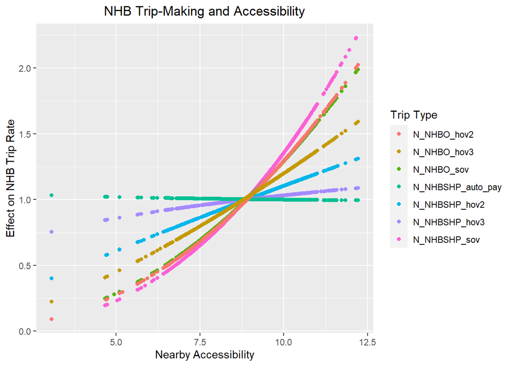

## Time of Day Adjustment

The independent feedback by time of day in the model presents a unique challenge for NHB. NHB and HB trips have very different time of day patterns (see Time of Day documentation), but NHB generation is simply rates multiplied by HB trip ends. Without correction, this would mean that the NHB trips would have the same distribution as HB trips. To correct this, Caliper calculated adjustment factors by tour type, mode, and time of day. This was done by comparing raw model outputs back to the observed NHB trips from the survey.

The easiest way to understand the table below is by highlighting one row as an example. For SOV trips on work tours, these factors move NHB trips out of the AM and NT periods and into the MD and PM. Another way of saying it is that, compared to HB trips, NHB trips are less likely in the AM/NT and more likely in the MD/PM. The large mid day factor reflects lunch trips and other mid-day activities. The relative size of the AM and PM periods confirms what we know: that stops are more likely to be made on the way home compared to the way to work (e.g. picking up groceries).

| Tour Type | Mode | AM | MD | NT | PM |
| --- | --- | --- | --- | --- | --- |
| NonWork | HOV2 | 0.74 | 1.38 | 2.07 | 1.54 |
| NonWork | HOV3 | 1.66 | 1.07 | 2.18 | 2.67 |
| NonWork | SOV | 0.60 | 1.50 | 0.43 | 0.72 |
| NonWork | Transit | 1.19 | 3.13 | 1.42 | 1.35 |
| NonWork | Nonmotorized | 1.33 | 3.20 | 1.14 | 0.53 |
| NonWork | Auto Pay | 1.00 | 1.22 | 2.33 | 2.86 |
| Work | Auto Pay | 0.53 | 5.93 | 3.57 | 5.44 |
| Work | HOV2 | 0.78 | 2.74 | 0.38 | 1.34 |
| Work | HOV3 | 2.00 | 3.90 | 1.55 | 4.69 |
| Work | SOV | 0.53 | 2.58 | 0.38 | 1.06 |
| Work | Transit | 0.29 | 2.11 | 2.25 | 0.79 |
| Work | Nonmotorized | 0.44 | 5.39 | 2.07 | 2.10 |